# Data Preprocessing in R

## Outlier Analysis

Outlier analysis might need to be performed as outliers can bias the model. But the action to be taken depends on the reason the outliers were introduced in the first place.In some cases it might so happen, that outliers are a different category altogether.

Visualizing could be done either by box plots or histograms.

```r
data(mtcars)
str(mtcars)
```

```
## 'data.frame':    32 obs. of  11 variables:
##  $ mpg : num  21 21 22.8 21.4 18.7 18.1 14.3 24.4 22.8 19.2 ...
##  $ cyl : num  6 6 4 6 8 6 8 4 4 6 ...
##  $ disp: num  160 160 108 258 360 ...
##  $ hp  : num  110 110 93 110 175 105 245 62 95 123 ...
##  $ drat: num  3.9 3.9 3.85 3.08 3.15 2.76 3.21 3.69 3.92 3.92 ...
##  $ wt  : num  2.62 2.88 2.32 3.21 3.44 ...
##  $ qsec: num  16.5 17 18.6 19.4 17 ...
##  $ vs  : num  0 0 1 1 0 1 0 1 1 1 ...
##  $ am  : num  1 1 1 0 0 0 0 0 0 0 ...
##  $ gear: num  4 4 4 3 3 3 3 4 4 4 ...
##  $ carb: num  4 4 1 1 2 1 4 2 2 4 ...
```

Lets introduce some outliers in the data first

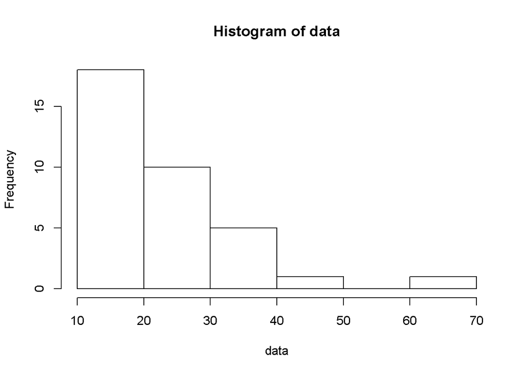

```r
df <- mtcars
outliers <- mtcars[1:3,]
outliers$mpg <- c(45,61,39)
df <- rbind(df,outliers)
data <- df$mpg
hist(data)
```

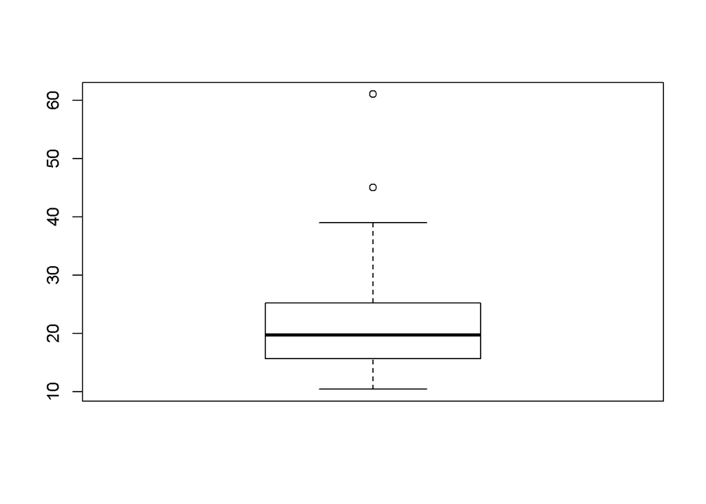

```r
boxplot(data)
```

Other than visual identification of outliers, we have some rules to identify mathematically. A basic one is two exclude anything more than 3 standard deviations from the mean.

```r
outlier_detect <- function(x,mean,sd) {
cut_off_lower <- -3*sd
cut_off_upper <- 3*sd
if (x<cut_off_lower | x> cut_off_upper) {
val <- 1}
else {
val <- 0
}
return(val)
}

mean_val = mean(data)
sd_val = sd(data)
mean_val
```

```
## [1] 22.51143
```

```r
sd_val
```

```
## [1] 10.25062
```

```r
outlier_flags <- sapply(data,outlier_detect,mean=mean_val,sd=sd_val)
head(data[outlier_flags==1])
```

```
## [1] 32.4 33.9 45.0 61.0 39.0
```

```r
length(data[outlier_flags==1])
```

```
## [1] 5
```

Another one is the Interquartile rule. Anything beyond Q1- 1.5 IQR or Q3 + 1.5 IQR is considered an outlier.

```r
outlier_detect_iqr <- function(x,q1,q3,iqr) {
cut_off_lower <- q1 - 1.5*iqr
cut_off_upper <- q3 + 1.5*iqr
if (x<cut_off_lower | x> cut_off_upper) {
val <- 1}
else {
val <- 0
}
return(val)
}

q1 <- quantile(data,0.25)
q3 <- quantile(data,0.75)
iqr <- IQR(data)

q1
```

```
##   25%
## 15.65
```

```r
q3
```

```
##  75%
## 25.2
```

```r
iqr
```

```
## [1] 9.55
```

```r
outlier_flags <- sapply(data,outlier_detect_iqr,q1=q1,q3=q3,iqr=iqr)
head(data[outlier_flags==1])
```

```
## [1] 45 61
```

```r
length(data[outlier_flags==1])
```

```
## [1] 2
```

But normally a univariate/bivariate analysis might not be suffient to detect outliers.This is where we might need to consider Cook’s distance.

It measures the impact of a data point on a predicted outcome. Assuming that there are two models, one which includes that particular data point and one without including that data point, cooks distance computes the squared difference in predictions of all points computed by these two models divided by p (number of coofficients of the model) and MSE (Mean squared error)

Normally observations which are 4 times the cooks distances, are treated as outliers.

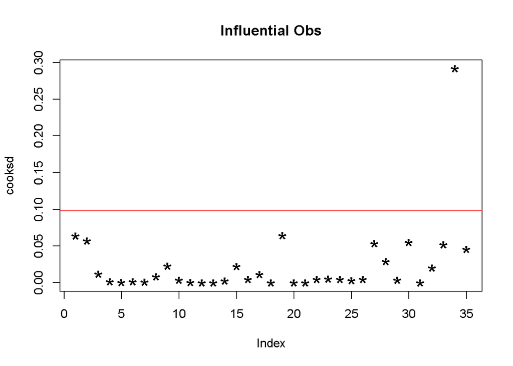

```r
mod <- lm(mpg ~ .,data=df)
cooksd <- cooks.distance(mod)
plot(cooksd,pch="*",cex=2,main="Influential Obs")
abline(h = 4*mean(cooksd, na.rm=T), col="red")
```

## Missing value imputations

Both outliers and missing values could require some method of dealing with them. First we need to identify the missing values. Using the same mtcars dataset, lets first introduce some missing values.

```r
df <- mtcars
df[c(10,12,20),"mpg"] <- NaN
sum(complete.cases(df))
```

```
## [1] 29
```

```r
sum(complete.cases(mtcars))
```

```
## [1] 32
```

```r
df[is.na(df),]
```

```
##                mpg cyl  disp  hp drat    wt qsec vs am gear carb
## Merc 280       NaN   6 167.6 123 3.92 3.440 18.3  1  0    4    4
## Merc 450SE     NaN   8 275.8 180 3.07 4.070 17.4  0  0    3    3
## Toyota Corolla NaN   4  71.1  65 4.22 1.835 19.9  1  1    4    1
```

We can see the three rows which have missing values. One way to deal with missing values, is to drop them.

```r
df2 <- na.omit(df)
sum(complete.cases(df2))
```

```
## [1] 29
```

```r
nrow(df2)
```

```
## [1] 29
```

The second method is to impute missing values with some value like mean, median or mode. Lets try mean imputation here.

```r
df3 <- df
df3[is.na(df3),"mpg"] <- mean(df[complete.cases(df),"mpg"])
sum(complete.cases(df3))
```

```
## [1] 32
```

There are other more sophisticated ways to impute values. Like knn imputation.

```r
library(caret)
df4 <- df
preProcValues <- preProcess(df4, method = c("knnImpute"),
                            k = 6,
                            knnSummary = mean)
impute_df <- predict(preProcValues, df4,na.action = na.pass)
```

But knn impute also centers and scales the data, which needs to be corrected post imputation. Lets write a function to correct this.

```r
center_scale_inverse <- function(x,colno) {
return (x*preProcValues$std[colno] + preProcValues$mean[colno])
}

for (colno in c(1:ncol(df4)))
 {
  impute_df[,colno] <- sapply(impute_df[,colno],center_scale_inverse,colno)
 }

sum(complete.cases(impute_df))
```

```
## [1] 32
```

```r
head(impute_df)
```

```
##                    mpg cyl disp  hp drat    wt  qsec vs am gear carb
## Mazda RX4         21.0   6  160 110 3.90 2.620 16.46  0  1    4    4
## Mazda RX4 Wag     21.0   6  160 110 3.90 2.875 17.02  0  1    4    4
## Datsun 710        22.8   4  108  93 3.85 2.320 18.61  1  1    4    1
## Hornet 4 Drive    21.4   6  258 110 3.08 3.215 19.44  1  0    3    1
## Hornet Sportabout 18.7   8  360 175 3.15 3.440 17.02  0  0    3    2
## Valiant           18.1   6  225 105 2.76 3.460 20.22  1  0    3    1
```

## Correlations

Next we check for correlations, to see if any of the correlated variables need to be removed.

```r
descr_corr <-  cor(impute_df)
descr_corr
```

```
##             mpg        cyl       disp         hp        drat         wt
## mpg   1.0000000 -0.8639041 -0.8630678 -0.7881252  0.68932447 -0.8700033
## cyl  -0.8639041  1.0000000  0.9020329  0.8324475 -0.69993811  0.7824958
## disp -0.8630678  0.9020329  1.0000000  0.7909486 -0.71021393  0.8879799
## hp   -0.7881252  0.8324475  0.7909486  1.0000000 -0.44875912  0.6587479
## drat  0.6893245 -0.6999381 -0.7102139 -0.4487591  1.00000000 -0.7124406
## wt   -0.8700033  0.7824958  0.8879799  0.6587479 -0.71244065  1.0000000
## qsec  0.4073028 -0.5912421 -0.4336979 -0.7082234  0.09120476 -0.1747159
## vs    0.6791547 -0.8108118 -0.7104159 -0.7230967  0.44027846 -0.5549157
## am    0.5853424 -0.5226070 -0.5912270 -0.2432043  0.71271113 -0.6924953
## gear  0.5000885 -0.4926866 -0.5555692 -0.1257043  0.69961013 -0.5832870
## carb -0.5383096  0.5269883  0.3949769  0.7498125 -0.09078980  0.4276059
##             qsec         vs          am       gear        carb
## mpg   0.40730275  0.6791547  0.58534237  0.5000885 -0.53830962
## cyl  -0.59124207 -0.8108118 -0.52260705 -0.4926866  0.52698829
## disp -0.43369788 -0.7104159 -0.59122704 -0.5555692  0.39497686
## hp   -0.70822339 -0.7230967 -0.24320426 -0.1257043  0.74981247
## drat  0.09120476  0.4402785  0.71271113  0.6996101 -0.09078980
## wt   -0.17471588 -0.5549157 -0.69249526 -0.5832870  0.42760594
## qsec  1.00000000  0.7445354 -0.22986086 -0.2126822 -0.65624923
## vs    0.74453544  1.0000000  0.16834512  0.2060233 -0.56960714
## am   -0.22986086  0.1683451  1.00000000  0.7940588  0.05753435
## gear -0.21268223  0.2060233  0.79405876  1.0000000  0.27407284
## carb -0.65624923 -0.5696071  0.05753435  0.2740728  1.00000000
```

```r
highly_corr <- findCorrelation(descr_corr, cutoff = .8)
colnames(impute_df)[highly_corr]
```

```
## [1] "cyl"  "disp" "mpg"
```

To know more details including the p-values, we use the Hmisc package

```r
library("Hmisc")
cor_coeff <- rcorr(as.matrix(impute_df))
cor_coeff$r
```

```
##             mpg        cyl       disp         hp        drat         wt
## mpg   1.0000000 -0.8639041 -0.8630678 -0.7881252  0.68932447 -0.8700033
## cyl  -0.8639041  1.0000000  0.9020329  0.8324475 -0.69993811  0.7824958
## disp -0.8630678  0.9020329  1.0000000  0.7909486 -0.71021393  0.8879799
## hp   -0.7881252  0.8324475  0.7909486  1.0000000 -0.44875912  0.6587479
## drat  0.6893245 -0.6999381 -0.7102139 -0.4487591  1.00000000 -0.7124406
## wt   -0.8700033  0.7824958  0.8879799  0.6587479 -0.71244065  1.0000000
## qsec  0.4073028 -0.5912421 -0.4336979 -0.7082234  0.09120476 -0.1747159
## vs    0.6791547 -0.8108118 -0.7104159 -0.7230967  0.44027846 -0.5549157
## am    0.5853424 -0.5226070 -0.5912270 -0.2432043  0.71271113 -0.6924953
## gear  0.5000885 -0.4926866 -0.5555692 -0.1257043  0.69961013 -0.5832870
## carb -0.5383096  0.5269883  0.3949769  0.7498125 -0.09078980  0.4276059
##             qsec         vs          am       gear        carb
## mpg   0.40730275  0.6791547  0.58534237  0.5000885 -0.53830962
## cyl  -0.59124207 -0.8108118 -0.52260705 -0.4926866  0.52698829
## disp -0.43369788 -0.7104159 -0.59122704 -0.5555692  0.39497686
## hp   -0.70822339 -0.7230967 -0.24320426 -0.1257043  0.74981247
## drat  0.09120476  0.4402785  0.71271113  0.6996101 -0.09078980
## wt   -0.17471588 -0.5549157 -0.69249526 -0.5832870  0.42760594
## qsec  1.00000000  0.7445354 -0.22986086 -0.2126822 -0.65624923
## vs    0.74453544  1.0000000  0.16834512  0.2060233 -0.56960714
## am   -0.22986086  0.1683451  1.00000000  0.7940588  0.05753435
## gear -0.21268223  0.2060233  0.79405876  1.0000000  0.27407284
## carb -0.65624923 -0.5696071  0.05753435  0.2740728  1.00000000
```

```r
cor_coeff$P
```

```
##               mpg          cyl         disp           hp         drat
## mpg            NA 1.917884e-10 2.090224e-10 8.558285e-08 1.281449e-05
## cyl  1.917884e-10           NA 1.803002e-12 3.477861e-09 8.244636e-06
## disp 2.090224e-10 1.803002e-12           NA 7.142679e-08 5.282022e-06
## hp   8.558285e-08 3.477861e-09 7.142679e-08           NA 9.988772e-03
## drat 1.281449e-05 8.244636e-06 5.282022e-06 9.988772e-03           NA
## wt   1.006000e-10 1.217567e-07 1.222311e-11 4.145827e-05 4.784260e-06
## qsec 2.068264e-02 3.660533e-04 1.314404e-02 5.766253e-06 6.195826e-01
## vs   1.922673e-05 1.843018e-08 5.235012e-06 2.940896e-06 1.167553e-02
## am   4.329383e-04 2.151207e-03 3.662114e-04 1.798309e-01 4.726790e-06
## gear 3.561694e-03 4.173297e-03 9.635921e-04 4.930119e-01 8.360110e-06
## carb 1.482269e-03 1.942340e-03 2.526789e-02 7.827810e-07 6.211834e-01
##                wt         qsec           vs           am         gear
## mpg  1.006000e-10 2.068264e-02 1.922673e-05 4.329383e-04 3.561694e-03
## cyl  1.217567e-07 3.660533e-04 1.843018e-08 2.151207e-03 4.173297e-03
## disp 1.222311e-11 1.314404e-02 5.235012e-06 3.662114e-04 9.635921e-04
## hp   4.145827e-05 5.766253e-06 2.940896e-06 1.798309e-01 4.930119e-01
## drat 4.784260e-06 6.195826e-01 1.167553e-02 4.726790e-06 8.360110e-06
## wt             NA 3.388683e-01 9.798492e-04 1.125440e-05 4.586601e-04
## qsec 3.388683e-01           NA 1.029669e-06 2.056621e-01 2.425344e-01
## vs   9.798492e-04 1.029669e-06           NA 3.570439e-01 2.579439e-01
## am   1.125440e-05 2.056621e-01 3.570439e-01           NA 5.834043e-08
## gear 4.586601e-04 2.425344e-01 2.579439e-01 5.834043e-08           NA
## carb 1.463861e-02 4.536949e-05 6.670496e-04 7.544526e-01 1.290291e-01
##              carb
## mpg  1.482269e-03
## cyl  1.942340e-03
## disp 2.526789e-02
## hp   7.827810e-07
## drat 6.211834e-01
## wt   1.463861e-02
## qsec 4.536949e-05
## vs   6.670496e-04
## am   7.544526e-01
## gear 1.290291e-01
## carb           NA
```

Lets flatten this matrix by writing a function

```r
flatten_corr <- function(cormat,pmat)
{
  ut <- upper.tri(cormat)
  df <- data.frame(
  row = rownames(cormat)[row(cormat)][ut],
  col = rownames(cormat)[col(cormat)][ut],
  cor = cormat[ut],
  p = pmat[ut]
  )
  return(df)
}

flat_cor <- flatten_corr(cor_coeff$r,cor_coeff$P)
head(flat_cor)
```

```
##    row  col        cor            p
## 1  mpg  cyl -0.8639041 1.917884e-10
## 2  mpg disp -0.8630678 2.090224e-10
## 3  cyl disp  0.9020329 1.803002e-12
## 4  mpg   hp -0.7881252 8.558285e-08
## 5  cyl   hp  0.8324475 3.477861e-09
## 6 disp   hp  0.7909486 7.142679e-08
```

For purely linear combinations, caret has a method called findLinearCombos

```r
comboInfo <- findLinearCombos(impute_df)
```

## Other Preprocessing

Many preprocessing requirements is dependent on the type of variables. Lets divide the columns into continuous and categorical variables.

```r
data("ToothGrowth")
df <- ToothGrowth

factor_variables <- lapply(df,is.factor)
numeric_variables <- lapply(df,is.numeric)

factor_variables
```

```
## $len
## [1] FALSE
##
## $supp
## [1] TRUE
##
## $dose
## [1] FALSE
```

```r
numeric_variables
```

```
## $len
## [1] TRUE
##
## $supp
## [1] FALSE
##
## $dose
## [1] TRUE
```

One important aspect of preprocessing is to create dummy variables for factor variables. Library caret can create dummy variables for all factor variables in a dataset

```r
df <- ToothGrowth
dummies <- dummyVars(~ ., data = df)
df_encoded <- predict(dummies, df)
head(df_encoded)
```

```
##    len supp.OJ supp.VC dose
## 1  4.2       0       1  0.5
## 2 11.5       0       1  0.5
## 3  7.3       0       1  0.5
## 4  5.8       0       1  0.5
## 5  6.4       0       1  0.5
## 6 10.0       0       1  0.5
```

Other commonly used preprocessing methods is to center and scale. Lets split the data into a train and test. Again caret library can be used to partition the data. We partition the data and then use the train split to train the preprocess method.

```r
set.seed(2341)
data(ToothGrowth)
df_part <- ToothGrowth
trainIndex <- createDataPartition(df_part$supp, p = 0.8, list = FALSE)
train_df <- df_part[trainIndex, ]
test_df <- df_part[-trainIndex, ]
preProcValues <- preProcess(train_df, method = c("center", "scale"))
trainTransformed <- predict(preProcValues, train_df)
testTransformed <- predict(preProcValues, test_df)
head(trainTransformed)
```

```
##          len supp     dose
## 1 -1.9077263   VC -1.08673
## 2 -0.9699214   VC -1.08673
## 3 -1.5094804   VC -1.08673
## 4 -1.7021800   VC -1.08673
## 8 -1.0084614   VC -1.08673
## 9 -1.7792599   VC -1.08673
```

```r
head(testTransformed)
```

```
##           len supp       dose
## 5  -1.6251002   VC -1.0867299
## 6  -1.1626211   VC -1.0867299
## 7  -1.0084614   VC -1.0867299
## 14 -0.2248162   VC -0.2842217
## 16 -0.2248162   VC -0.2842217
## 28  0.3147427   VC  1.3207947
```